# ManyBabiesPowerAnalysisWorkshopPart1

Chris Cox

2024-03-06

# Introduction to Data Simulation

Let’s start by loading the required packages:

```r
#if you don't have the pacman package loaded on your computer, uncomment the next line, install pacman, and load in the required packages
#install.packages('pacman')
#load the required packages:
pacman::p_load(knitr, # rendering of .Rmd file
               lme4, # model specification / estimation
               afex, # anova and deriving p-values from lmer
               broom.mixed, # extracting data from model fits
               faux, # generate correlated values
               tidyverse, # data wrangling and visualisation
               ggridges, #visualisation
               viridis, # color schemes for visualisation
               kableExtra, #helps with knitting the .Rmd file
               cowplot, #visualisation tool to include multiple plots
               MASS,
               ggrain)
set.seed(1234)
opts_chunk$set(tidy.opts=list(width.cutoff=60),tidy=TRUE, fig.width=12, fig.height=11, fig.fullwidth=TRUE)

plot_theme <-
  theme_bw() +
  theme(plot.title = element_text(hjust = 0.5, size = 18),
        legend.position = "none",
        axis.text.x = element_text(size = 13),
        axis.title.x = element_text(size = 13),
        axis.text.y = element_text(size = 12),
        axis.title.y = element_text(size = 13))
```

Let’s start with a straightforward example based on MB1. We are interested in the following question: To what extent do infants demonstrate longer looking times to infant-directed speech as opposed to adult-directed speech? We know that a linear mixed-effects model is an appropriate modelling strategy, so we want to conduct a power analysis with this in mind.

To give an overview of the simulation task, we will simulate data from a design with crossed random factors of subjects and stimuli, fit a model to the simulated data, and then see whether the resulting sample estimates are similar to the population values we specified when simulating the data. In this study, infant participants are exposed to recordings of infant-directed and adult-directed speech, and we use their looking times as the primary dependent variable. The key question is whether there is any behavioural differences within each participants according to the type of stimulus.

## Establishing the data-generating parameters

Now that we have an overview of a dataset that would make sense for our experimental design, let’s start to make some realistic and informed choices for parameters that would make sense to build a statistical model. In the following sections, we will build up the parameters for a mixed-effects statistical model of the following type, as described in the lecture:

DV = β₀ + β₁ * SpeechStyle + u₀ⱼ^(item) + u₀ᵢ^(subj) + (u₁ᵢ^(subj) * SpeechStyle) + ε

According to this formula, the dependent variable for each subject and item is defined as sum of an intercept term 𝛽0, which in this example is the grand mean reaction time for the population of stimuli, plus 𝛽1, the mean RT difference ADS and IDS stimuli, plus random noise. To make 𝛽0 equal the grand mean and 𝛽1 equal the mean IDS minus the mean ADS RT, we will code the SpeechStyle category variable -0.5 for ADS and +0.5 for IDS.

The response time for subject 𝑠on item 𝑖, 𝑅𝑇𝑠𝑖, is decomposed into a population grand mean 𝛽0, a by-subject random intercept 𝑇0𝑠, a by-item random intercept 𝑂0𝑖, a fixed slope 𝛽1, a by-subject random slope 𝑇1𝑠, and a trial-level residual 𝑒𝑠𝑖. Our data-generating process is fully determined by seven population parameters, all denoted by Greek letters: 𝛽0, 𝛽1, 𝜏0, 𝜏1, 𝜌, 𝜔0, and 𝜎. In the next section we will apply this data-generating process to simulate the sampling of subjects, items, and trials (encounters).

- the usual standard deviation of the residuals (i.e., ‘sigma’),
- the standard deviation of the population of by-subject varying intercepts (i.e., ‘Intercept’), and
- the standard deviation of the population of by-subject varying slopes (i.e., ‘RegisterIDS’).

The latter two sources of variation provide one of the most essential features of multi-level models: partial pooling, as we discussed in the lecture.

In the model formula, we use Greek letters (𝛽0, 𝛽1) to represent population parameters that are being directly estimated by the model. In contrast, Roman letters represent the remaining variables: observed variables whose values are determined by sampling (e.g., 𝑅𝑇𝑠𝑖, 𝑇0𝑠, 𝑒𝑠𝑖) or fixed by the experiment design (𝑋𝑖).

Let’s start by setting the fixed-effects parameters; that is, the overall intercept (ADS) and the effect of speech style (IDS). We can be informed about these choices from what we know about looking times in infant expperiments. We could imagine a looking time of around 9 seconds (i.e., 9000ms) for ADS stimuli and for infants to exhibit longer looking times towards IDS stimuli, maybe around 11 seconds (i.e., 11000 ms), or 2000 ms longer looking times than that to ADS. Let’s code this explicitly as parameter values in for our simulation:

```r
# set fixed effect parameters
beta_0 <- 9000  # intercept; i.e., the grand mean, ADS
beta_1 <- 2000  # slope; i.e, effect of IDS
```

We also need to add some variability around these values, as we can’t expect each and every infant in the experiment to have exactly the same baseline reaction to the ADS stimuli, and we can’t expect each stimulus to have exactly the same effect. We would expect variability in both subject reactions and item effects. Let’s code this as standard deviation of by-subject random intercept and by-item random intercept sd.

```r
# set random effect parameters
tau_0 <- 3000  # by-subject random intercept sd
omega_0 <- 1000  # by-item random intercept sd
```

We also can’t expect the effect of IDS stimuli to be the same for every infant; that is, some infants’ attention may be more grabbed by IDS stimuli than others, and we therefore need to add subject-specific variability for the effect of IDS on looking times. Let’s code this as the tau_1 parameter. Here we can also add a crucial component of multi-level models, which is the correlation matrix. There may be patterns in the data between those infants who have a high looking time baseline in ADS and the effects of IDS, and we therefore have to add a correlation matrix to account for these patterns. Here, we specify that there is a weak correlation between the varying intercepts and varying slopes of infant participants. We also need a residual error term to capture unexplained sources of variability:

```r
# set more random effect and error parameters
tau_1 <- 1000  # by-subject random slope sd
rho <- 0.2  # correlation between intercept and slope
sigma <- 500  # residual (error) sd
```

## Define parameters for observations

```r
# set number of subjects and items
n_subj <- 24  # number of subjects
n_ADS <- 8  # number of ADS stimuli
n_IDS <- 8  # number of IDS stimuli
```

## Simulate the sampling of stimulus items

```r
# simulate a sample of items
# total number of items = n_ADS + n_IDS
items <- data.frame(
  #item_id = seq_len(n_ADS + n_IDS),
  Register = rep(c("IDS", "ADS"), c(n_ADS, n_IDS)),
  O_0i = rnorm(n = n_ADS + n_IDS, mean = 0, sd = omega_0)
) %>%
  mutate(item_id = faux::make_id(nrow(.), "I")) %>%
  mutate(SpeechStyle = recode(Register, "ADS" = -0.5, "IDS" = +0.5))

#let's have a look at what this has produced:
glimpse(items)
```

```
## Rows: 16
## Columns: 4
## $ Register    <chr> "IDS", "IDS", "IDS", "IDS", "IDS", "IDS", "IDS", "IDS", "A…
## $ O_0i        <dbl> -1207.06575, 277.42924, 1084.44118, -2345.69770, 429.12469…
## $ item_id     <chr> "I01", "I02", "I03", "I04", "I05", "I06", "I07", "I08", "I…
## $ SpeechStyle <dbl> 0.5, 0.5, 0.5, 0.5, 0.5, 0.5, 0.5, 0.5, -0.5, -0.5, -0.5, …
```

Let us introduce a numeric predictor to represent what category each stimulus item 𝑖 appears in (i.e., for the 𝑋𝑖 in our model). Since we predict that looking times to ADS stimuli will be shorter than IDS stimuli, we set ADS to be -0.5 and IDS to be +0.5. This is what is known as contrast coding, and we will later multiply this effect-coded factor by the fixed effect of category to simulate data where the ADS stimuli on average generate looking times of -1000 ms different from the grand mean, while the IDS stimuli are on average 1000 ms different from the grand mean.

In R, most regression procedures can handle two-level factors like category as predictor variables. By default, the procedure will create a new numeric predictor that codes one level of the factor as zero and the other as one. Why not just use the defaults? The short explanation is that the default of 0, 1 coding is not well-suited to the kinds of factorial experimental designs often found in psychology and related fields. For the current example, using the default coding for the 𝑋 predictor would change the interpretation of 𝛽0: instead of the grand mean, it would reflect the mean for the group coded as zero. One could change the default, but we feel it is better to be explicit in the code about what values are being used.

## Simulate the sampling of subjects

Now we will simulate the sampling of individual subjects, resulting in a table listing each subject and their two correlated varying effects (i.e., intercepts and slopes). This will be slightly more complicated that what we just did, because we cannot simply sample the 𝑇0𝑠 values from a univariate distribution using rnorm() independently from the 𝑇1𝑠 values. Instead, we must sample ⟨𝑇0𝑠,𝑇1𝑠⟩ pairs — one pair for each subject—from a bivariate normal distribution. One way to sample from a bivariate distribution would be to use the function rnorm_multi() from the faux package (DeBruine 2020), which generates a table of n simulated values from a multivariate normal distribution by specifying the means (mu) and standard deviations (sd) of each variable, plus the correlations (r), which can be either a single value (applied to all pairs), a correlation matrix, or a vector of the values in the upper right triangle of the correlation matrix.

```r
# simulate a sample of subjects

# sample from a multivariate random distribution
subjects <- faux::rnorm_multi(
  n = n_subj,
  mu = 0, # means for random effects are always 0
  sd = c(tau_0, tau_1), # set SDs
  r = rho, # set correlation, see ?faux::rnorm_multi
  varnames = c("T_0s", "T_1s")
) %>%
  mutate(subj_id = faux::make_id(nrow(.), "S"))
```

## Simulate trials (encounters)

Since all subjects respond to all items, we can set up a table of trials by making a table with every possible combination of the rows in the subject and item tables using the tidyverse function crossing(). Each trial has random error associated with it, reflecting fluctuations in trial-by-trial performance due to unknown factors; we simulate this by sampling values from a normal distribution with a mean of 0 and SD of sigma.

```r
# cross subject and item IDs; add an error term nrow(.) is
# the number of rows in the table
ParameterValues <- crossing(subjects, items) %>%
    mutate(e_si = rnorm(nrow(.), mean = 0, sd = sigma)) %>%
    dplyr::select(subj_id, item_id, Register, SpeechStyle, everything())
```

## Adding it all together

Now we have specified the parameters in ParameterValues, we are ready to add up everything together to create the response variable (i.e., infant looking times in milliseconds). To be more specific, we calculate the response variable, looking time, by adding together:

- the grand intercept (beta_0),
- each subject-specific random intercept (T_0s),
- each item-specific random intercept (O_0i),
- each sum of the category effect (beta_1) and the random slope (T_1s), multiplied by the numeric predictor (SpeechStyle), and
- each residual error (e_si).

After this we will use dplyr::select() to keep the columns we need. This will create the structure that we set as our goal at the start of this exercise, with the additional column SpeechStyle, which we will keep to use in the estimation process, described in the next section.

```r
# calculate the response variable
dat_sim <- ParameterValues %>%
    mutate(LT = beta_0 + T_0s + O_0i + (beta_1 + T_1s) * SpeechStyle +
        e_si) %>%
    mutate(LT = LT + rexp(nrow(.), rate = 3e-04)) %>%
    dplyr::select(subj_id, item_id, Register, SpeechStyle, LT)
```

Let’s have a look at what the data we have generated looks like:

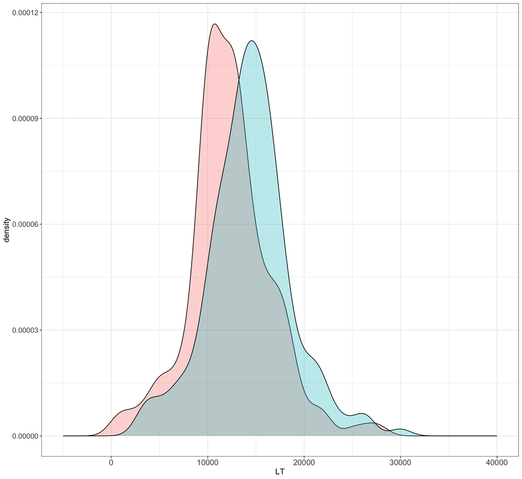

```r
dat_sim %>%
    ggplot() + geom_density(aes(x = LT, fill = as.factor(SpeechStyle)),
    alpha = 0.3) + xlim(c(-5000, 40000)) + plot_theme
```

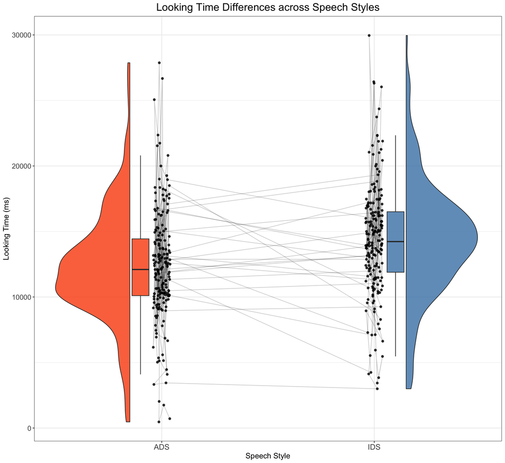

```r
dat_sim_plot <- dat_sim %>%
    group_by(subj_id, Register) %>%
    dplyr::summarise(medLT = mean(LT))
ggplot(aes(x = Register, y = LT, fill = Register), data = dat_sim) +
    geom_rain(alpha = 0.8, rain.side = "f1x1", id.long.var = "subj_id",
        point.args.pos = list(position = position_jitter(width = 0.04,
            height = 0, seed = 42)), line.args.pos = list(position = position_jitter(width = 0.04,
            height = 0, seed = 42))) + scale_fill_manual(values = c("#FC4E07",
    "steelblue")) + ggtitle("Looking Time Differences across Speech Styles") +
    xlab("Speech Style") + ylab("Looking Time (ms)") + scale_color_manual(values = viridis(n = 27)) +
    plot_theme
```

```r
# set up the custom data simulation function
SimulateData <- function(
  n_subj = 24,   # number of subjects
  n_ADS  = 8,   # number of ingroup stimuli
  n_IDS =  8,   # number of outgroup stimuli
  beta_0 = 9000,   # grand mean
  beta_1 =  3000,   # effect of category
  omega_0 =  1000,   # by-item random intercept sd
  tau_0 = 2000,   # by-subject random intercept sd
  tau_1 =  2500,   # by-subject random slope sd
  rho = 0.5,   # correlation between intercept and slope
  sigma = 200) { # residual (standard deviation)

  items <- data.frame(
  #item_id = seq_len(n_ADS + n_IDS),
  Register = rep(c("IDS", "ADS"), c(n_ADS, n_IDS)),
  O_0i = rnorm(n = n_ADS + n_IDS, mean = 0, sd = omega_0)) %>%
  mutate(item_id = faux::make_id(nrow(.), "I")) %>%
  mutate(SpeechStyle = recode(Register, "ADS" = -0.5, "IDS" = +0.5))

  # simulate a sample of subjects

# sample from a multivariate random distribution
  subjects <- faux::rnorm_multi(
  n = n_subj,
  mu = 0, # means for random effects are always 0
  sd = c(tau_0, tau_1), # set SDs
  r = rho, # set correlation, see ?faux::rnorm_multi
  varnames = c("T_0s", "T_1s")
) %>%
  mutate(subj_id = faux::make_id(nrow(.), "S"))

  ParameterValues <- crossing(subjects, items)  %>%
    mutate(e_si = rnorm(nrow(.), mean = 0, sd = sigma)) %>%
    dplyr::select(subj_id, item_id, Register, SpeechStyle, everything())

  dat_sim <- ParameterValues %>%
    mutate(LT = beta_0 + T_0s + O_0i + (beta_1 + T_1s) * SpeechStyle + e_si) %>%
    mutate(LT = LT + rexp(nrow(.), rate = 0.0003)) %>%
    dplyr::select(subj_id, item_id, Register, SpeechStyle, LT)
}
```

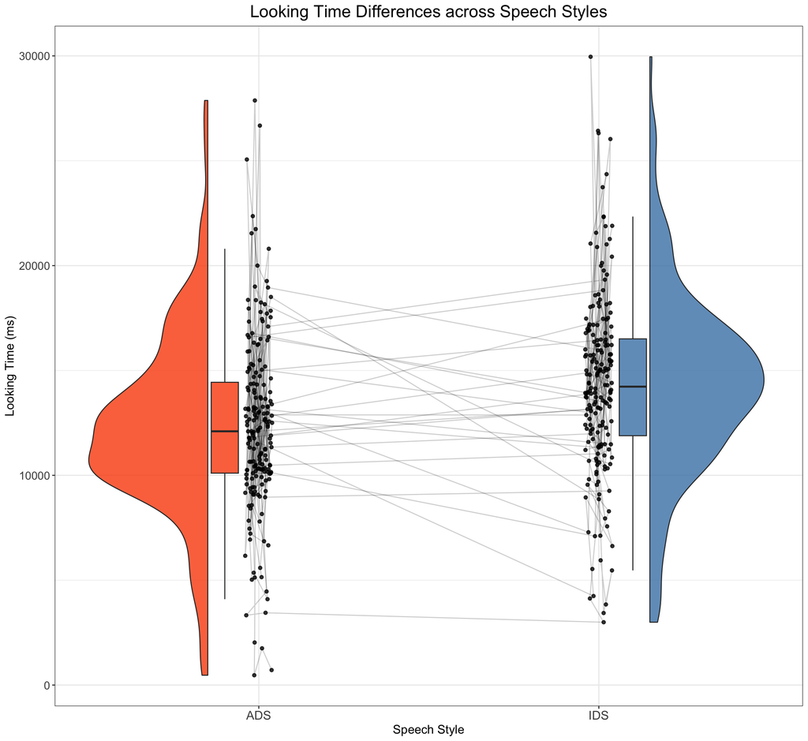

```r
data <- SimulateData(n_subj = 500, beta_1 = 0)

dat_sim_plot <- data %>%
    group_by(subj_id, Register) %>%
    dplyr::summarise(medLT = mean(LT))
ggplot(aes(x = Register, y = LT, fill = Register), data = dat_sim) +
    geom_rain(alpha = 0.8, rain.side = "f1x1", id.long.var = "subj_id",
        point.args.pos = list(position = position_jitter(width = 0.04,
            height = 0, seed = 42)), line.args.pos = list(position = position_jitter(width = 0.04,
            height = 0, seed = 42))) + scale_fill_manual(values = c("#FC4E07",
    "steelblue")) + ggtitle("Looking Time Differences across Speech Styles") +
    xlab("Speech Style") + ylab("Looking Time (ms)") + scale_color_manual(values = viridis(n = 27)) +
    plot_theme
```

Let’s think about how we want to run a generalised linear mixed-effects model of the data. For a varying intercepts, varying slopes model for each subject, we could run the following model with the lmer syntax as follows:

- LT ~ 1 + SpeechStyle + (1 | item_id) + (1 + SpeechStyle | subj_id)

The terms in parentheses with the “pipe” separator (|) define the random effects structure. For each of these bracketed terms, the left-hand side of the pipe names the effects you wish to allow to vary and the right hand side names the variable identifying the levels of the random factor over which the terms vary (e.g., subjects or items). The first term, (1 | item_id) allows the intercept (1) to vary over the random factor of items (item_id). This is an instruction to estimate the parameter underlying the O_0i values, namely omega_0. The second term, (1 + X_i | subj_id), allows both the intercept and the effect of category (coded by X_i) to vary over the random factor of subjects (subj_id). It is an instruction to estimate the three parameters that underlie the T_0s and T_1s values, namely tau_0, tau_1, and rho.

Given that looking time data tends to be right-skewed, we can model the data using a logarithmic link function to take this into account. The GLMM would look as follows. We will use the summary() function to view the results.

```r
dataSimulated <- SimulateData()

model <- glmer(LT ~ 1 + SpeechStyle + (1 | item_id) + (1 + SpeechStyle |
    subj_id), data = dataSimulated, family = Gamma(link = "log"))

summary(model)
```

```
## Generalized linear mixed model fit by maximum likelihood (Laplace
##   Approximation) [glmerMod]
##  Family: Gamma  ( log )
## Formula: LT ~ 1 + SpeechStyle + (1 | item_id) + (1 + SpeechStyle | subj_id)
##    Data: dataSimulated
##
##      AIC      BIC   logLik deviance df.resid
##   7357.5   7385.2  -3671.8   7343.5      377
##
## Scaled residuals:
##     Min      1Q  Median      3Q     Max
## -2.6789 -0.6401 -0.1412  0.4258  3.9262
##
## Random effects:
##  Groups   Name        Variance Std.Dev. Corr
##  subj_id  (Intercept) 0.009583 0.09789
##           SpeechStyle 0.039367 0.19841  0.24
##  item_id  (Intercept) 0.007222 0.08498
##  Residual             0.083845 0.28956
## Number of obs: 384, groups:  subj_id, 24; item_id, 16
##
## Fixed effects:
##             Estimate Std. Error t value Pr(>|z|)
## (Intercept)  9.38583    0.05888 159.406   <2e-16 ***
## SpeechStyle  0.22297    0.11876   1.877   0.0605 .
## ---
## Signif. codes:  0 '***' 0.001 '**' 0.01 '*' 0.05 '.' 0.1 ' ' 1
##
## Correlation of Fixed Effects:
##             (Intr)
## SpeechStyle 0.155
```

Great, so now we have a way of generating data for our research question, and we have a clear idea of how we want to model the data. Now it’s time to run the actual power analysis. The way we do this is to specify an effect, run a model and count how many of the models show significant effects (i.e., the ground truth).

```r
# simulate, analyze, and return a table of parameter
# estimates
single_run <- function(...) {
    # ... is a shortcut that forwards any arguments to
    # my_sim_data(), the function created above
    dataSimulated <- SimulateData()

    model <- lmer(LT ~ 1 + SpeechStyle + (1 | item_id) + (1 +
        SpeechStyle | subj_id), data = dataSimulated)
    # family = gaussian(link = 'log'))

    broom.mixed::tidy(model)
}
single_run()
```

```
## # A tibble: 7 × 8
##   effect   group    term            estimate std.error statistic    df   p.value
##   <chr>    <chr>    <chr>              <dbl>     <dbl>     <dbl> <dbl>     <dbl>
## 1 fixed    <NA>     (Intercept)      1.31e+4      607.     21.6   28.0  5.53e-19
## 2 fixed    <NA>     SpeechStyle      4.27e+3      912.      4.68  27.2  7.06e- 5
## 3 ran_pars subj_id  sd__(Intercept)  2.59e+3       NA      NA     NA   NA
## 4 ran_pars subj_id  cor__(Intercep…  5.84e-1       NA      NA     NA   NA
## 5 ran_pars subj_id  sd__SpeechStyle  3.38e+3       NA      NA     NA   NA
## 6 ran_pars item_id  sd__(Intercept)  9.32e+2       NA      NA     NA   NA
## 7 ran_pars Residual sd__Observation  3.63e+3       NA      NA     NA   NA
```

Now we have a function to generate data, run our model and spit out the results! Now it’s time to repeat a few hundred times, so that we can calculate how much power we have with our given parameters!

```r
# run simulations and save to a file
n_runs <- 100 # use at least 100 to get stable estimates
sims <- purrr::map_df(1:n_runs, ~ single_run())
```

```
## boundary (singular) fit: see help('isSingular')
## boundary (singular) fit: see help('isSingular')
## boundary (singular) fit: see help('isSingular')
```

```r
write_csv(sims, "sims.csv")

# read saved simulation data
sims <- read_csv("sims.csv", col_types = cols(
  # makes sure plots display in this order
  group = col_factor(ordered = TRUE),
  term = col_factor(ordered = TRUE)
  ))

sims %>%
  filter(effect == "fixed") %>%
  dplyr::select(term, estimate, p.value)
```

```
## # A tibble: 200 × 3
##    term        estimate  p.value
##    <fct>          <dbl>    <dbl>
##  1 (Intercept)   12665. 8.49e-21
##  2 SpeechStyle    3050. 1.01e- 4
##  3 (Intercept)   12491. 5.50e-21
##  4 SpeechStyle    2612. 2.00e- 3
##  5 (Intercept)   12362. 6.28e-19
##  6 SpeechStyle    3138. 4.83e- 5
##  7 (Intercept)   11495. 1.03e-20
##  8 SpeechStyle    2145. 6.67e- 3
##  9 (Intercept)   12797. 1.84e-21
## 10 SpeechStyle    5282. 1.48e- 7
## # ℹ 190 more rows
```

```r
# calculate mean estimates and power for specified alpha
alpha <- 0.05

sims %>%
  filter(effect == "fixed") %>%
  group_by(term) %>%
  dplyr::summarize(
    mean_estimate = mean(estimate),
    mean_se = mean(std.error),
    power = mean(p.value < alpha),
    .groups = "drop"
  )
```

```
## # A tibble: 2 × 4
##   term        mean_estimate mean_se power
##   <fct>               <dbl>   <dbl> <dbl>
## 1 (Intercept)        12440.    502.  1
## 2 SpeechStyle         3053.    793.  0.94
```

Exercise 1: Let’s explore the effect of repeated measures on power. Try to run a power analysis with each subject receiving two items and another power analysis with each subject receiving 15 items. What happens to the estimate of statistical power?

Write your answer here:

Exercise 2: We might expect the IDS preference effect to change with infant age, such that older infants listen longer to IDS over ADS than younger infants. How would you add a positive interaction effect of (cross-sectional) age as a predictor to the model (hint: it involves randomly sampling age for each child and adding an effect to the simulation code and model)?